# Developing Different Forecasting Strategies for Different Type of Products

At this point, we can try to model the random component of the daily decomposition with an ARIMA model. First we need to check the properties of the random component.

```r
random_5=dcmp_5$daily$random
data_5[,trend:=dcmp_5$daily$trend]
data_5[,seasonal:=dcmp_5$daily$seasonal]
data_5[,random:=random_5]
summary(ur.kpss(random_5))
```

```
##
## #######################
## # KPSS Unit Root Test #
## #######################
##
## Test is of type: mu with 5 lags.
##
## Value of test-statistic is: 0.0069
##
## Critical value for a significance level of:
##                 10pct  5pct 2.5pct  1pct
## critical values 0.347 0.463  0.574 0.739
```

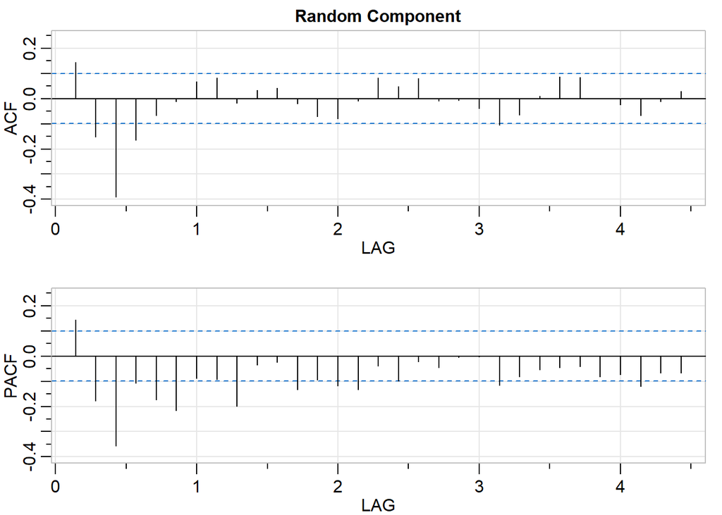

```
##      [,1]  [,2]  [,3]  [,4]  [,5]  [,6]  [,7]  [,8]  [,9] [,10] [,11] [,12]
## ACF  0.14 -0.15 -0.39 -0.16 -0.07 -0.01  0.07  0.08 -0.02  0.03  0.04 -0.02
## PACF 0.14 -0.18 -0.36 -0.11 -0.17 -0.22 -0.09 -0.09 -0.20 -0.03 -0.02 -0.13
##      [,13] [,14] [,15] [,16] [,17] [,18] [,19] [,20] [,21] [,22] [,23] [,24]
## ACF  -0.07 -0.08 -0.01  0.08  0.05  0.08 -0.01 -0.01 -0.04 -0.11 -0.06  0.01
## PACF -0.10 -0.12 -0.13 -0.04 -0.10 -0.02 -0.04 -0.01  0.00 -0.12 -0.08 -0.05
##      [,25] [,26] [,27] [,28] [,29] [,30] [,31]
## ACF   0.09  0.08  0.00 -0.02 -0.07 -0.01  0.03
## PACF -0.05 -0.04 -0.08 -0.07 -0.12 -0.07 -0.07
```

```r
acf2(random_5, main="Random Component")
```

It can be assumed stationary and ACF and PACF suggest that there is some level of dependency among the observations. Note that there is no seasonality effect on the random component as expected. An ARIMA model can be suitable. MA model would not be appropriate for this series but AR model may be suitable. We can try couple of models and compare them based on AIC values. Note that ACF and PACF is very similar to those of product 4.

```r
ar_5_1=arima(random_5, order=c(3,0,0))
ar_5_2=arima(random_5, order=c(4,0,0))
ar_5_3=arima(random_5, order=c(5,0,0))
arma_5_1=arima(random_5, order=c(3,0,1))
arma_5_2=arima(random_5, order=c(4,0,1))
arma_5_3=arima(random_5, order=c(5,0,1))
c(ar1=AIC(ar_5_1), ar2=AIC(ar_5_2), ar3=AIC(ar_5_3), arma1=AIC(arma_5_1), arma2=AIC(arma_5_2), arma3=AIC(arma_5_3))
```

```
##      ar1      ar2      ar3    arma1    arma2    arma3
## 4845.071 4842.354 4832.047 4757.560 4757.842 4752.595
```

ARIMA(5,0,1) provides the best AIC value. We can check their performance on the training data.

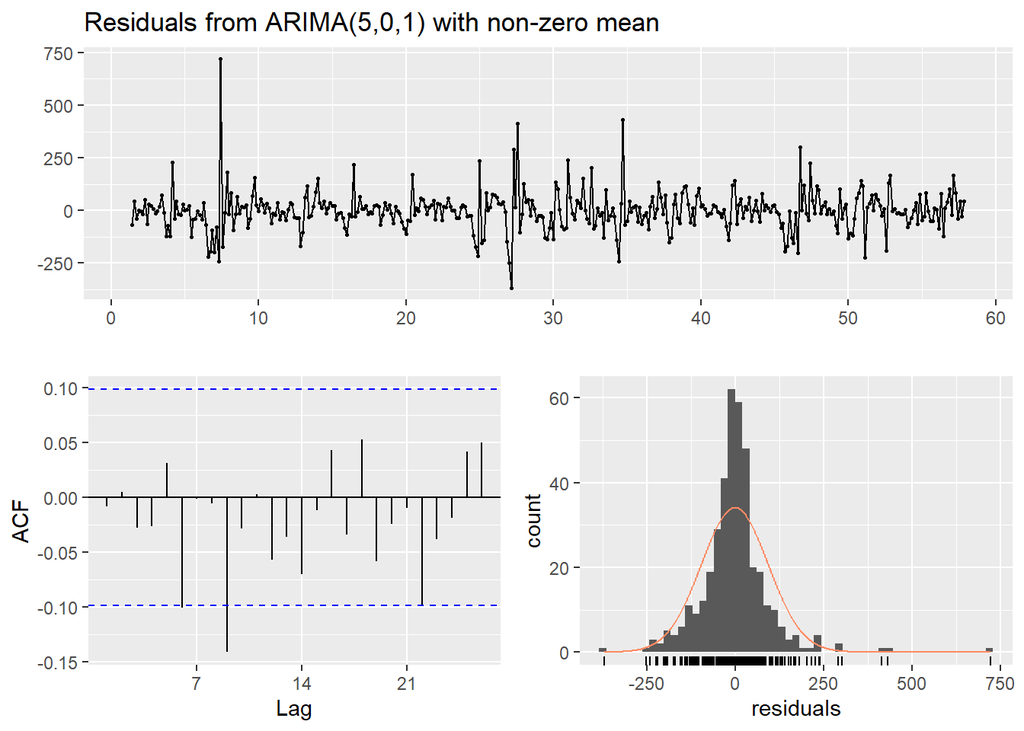

```
##
##  Ljung-Box test
##
## data:  Residuals from ARIMA(5,0,1) with non-zero mean
## Q* = 17.394, df = 7, p-value = 0.01502
##
## Model df: 7.   Total lags used: 14
```

```r
checkresiduals(arma_5_3)
```

Assumptions seem to hold somehow.

```r
data_5[,fitted_3_0:=random_5-ar_5_1$residuals+dcmp_5$daily$trend+dcmp_5$daily$seasonal]
data_5[,fitted_4_0:=random_5-ar_5_2$residuals+dcmp_5$daily$trend+dcmp_5$daily$seasonal]
data_5[,fitted_5_0:=random_5-ar_5_3$residuals+dcmp_5$daily$trend+dcmp_5$daily$seasonal]
data_5[,fitted_3_1:=random_5-arma_5_1$residuals+dcmp_5$daily$trend+dcmp_5$daily$seasonal]
data_5[,fitted_4_1:=random_5-arma_5_2$residuals+dcmp_5$daily$trend+dcmp_5$daily$seasonal]
data_5[,fitted_5_1:=random_5-arma_5_3$residuals+dcmp_5$daily$trend+dcmp_5$daily$seasonal]

melted_result=melt(data_5, c("event_date","sold_count"),
                   c("fitted_3_0","fitted_4_0", "fitted_5_0", "fitted_3_1",
                     "fitted_4_1","fitted_5_1"))

performance=melted_result[,accu_na(sold_count, value), by=list(variable)]
performance
```

```
##      variable   n     mean       sd        CV         FBias      MAPE      RMSE
## 1: fitted_3_0 396 395.8939 213.2945 0.5387668 -0.0001277620 0.1994292 108.34601
## 2: fitted_4_0 396 395.8939 213.2945 0.5387668 -0.0001614213 0.1967913 107.69624
## 3: fitted_5_0 396 395.8939 213.2945 0.5387668 -0.0002129706 0.1936901 106.01472
## 4: fitted_3_1 396 395.8939 213.2945 0.5387668 -0.0042021638 0.1800426  96.09435
## 5: fitted_4_1 396 395.8939 213.2945 0.5387668 -0.0039762721 0.1788914  95.90046
## 6: fitted_5_1 396 395.8939 213.2945 0.5387668 -0.0043238560 0.1780623  94.98548
##         MAD      MADP     WMAPE
## 1: 69.00915 0.1743122 0.1743122
## 2: 68.33089 0.1725990 0.1725990
## 3: 66.99280 0.1692191 0.1692191
## 4: 62.25650 0.1572555 0.1572555
## 5: 61.78140 0.1560554 0.1560554
## 6: 61.51150 0.1553737 0.1553737
```

We see that ARIMA(5,0,1) gives the best result.

Now we can add some regressors to the model. Again note that these are lagged variables.

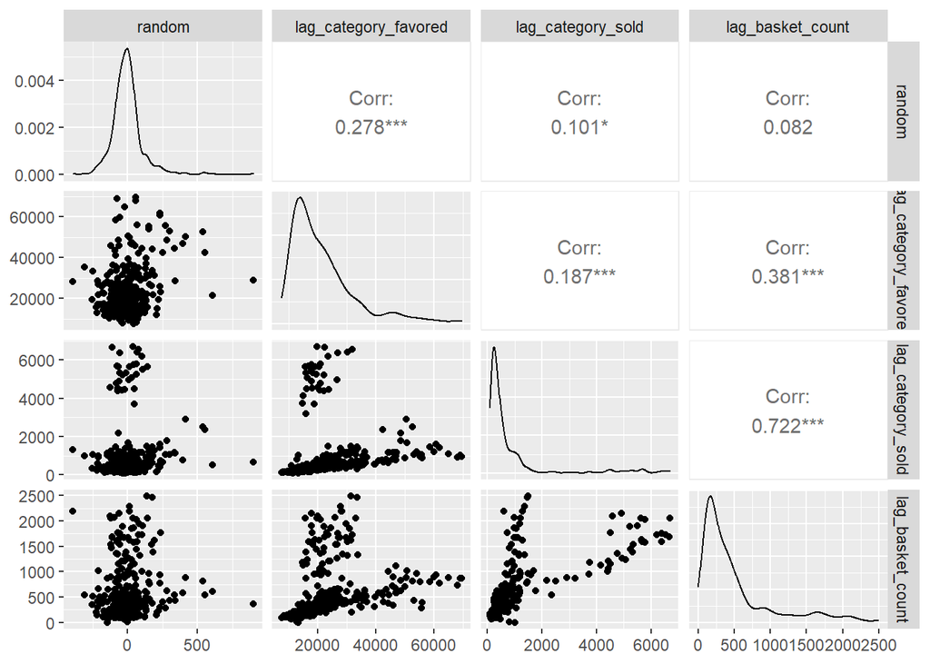

```r
ggpairs(data_5[,c("random","lag_category_favored","lag_category_sold","lag_basket_count")])
```

```r
lm_5=lm(random~lag_category_favored, data=data_5)
summary(lm_5)
```

```
##
## Call:
## lm(formula = random ~ lag_category_favored, data = data_5)
##
## Residuals:
##     Min      1Q  Median      3Q     Max
## -407.74  -58.54   -2.40   46.06  880.18
##
## Coefficients:
##                        Estimate Std. Error t value Pr(>|t|)
## (Intercept)          -6.253e+01  1.228e+01   -5.09 5.55e-07 ***
## lag_category_favored  2.849e-03  4.964e-04    5.74 1.89e-08 ***
## ---
## Signif. codes:  0 '***' 0.001 '**' 0.01 '*' 0.05 '.' 0.1 ' ' 1
##
## Residual standard error: 114.7 on 394 degrees of freedom
##   (6 observations deleted due to missingness)
## Multiple R-squared:  0.07718,    Adjusted R-squared:  0.07484
## F-statistic: 32.95 on 1 and 394 DF,  p-value: 1.889e-08
```

It is very significant but R-squared value is too small. Nevertheless we can try to add this variable to the ARIMA(5,0,1) model.

Now we compare ARIMA(5,0,1) and the new ARIMAX model on the test period.

```r
results=vector('list',length(test_dates))
for(i in 1:length(test_dates)){
  current_date=test_dates[i]-forecast_ahead

  past_data=data_5[event_date<=current_date]
  forecast_data=data_5[event_date==test_dates[i]]

  # arima model
  frcst=arima(past_data[,ts(random)], order=c(5,0,1))
  frcst=forecast(frcst, h=forecast_ahead)
  forecast_data[,arima_prediction:=round(frcst$mean[2]+as.numeric(trend)+as.numeric(seasonal), 0)]

  # arimax model
  reg = matrix(past_data[,lag_category_favored], ncol=1)
  frcst=auto.arima(past_data[,ts(random)],max.p=5,start.p=5,max.q=1,start.q=1,xreg=reg,seasonal=FALSE,stepwise=FALSE,approximation=FALSE)
  reg = matrix(past_data[(.N-1):.N, category_favored], ncol=1)
  frcst=forecast(frcst, h=forecast_ahead, xreg=reg)
  forecast_data[,arimax_prediction:=round(frcst$mean[2]+as.numeric(trend)+as.numeric(seasonal), 0)]

  results[[i]]=forecast_data
}
overall_results=rbindlist(results)
melted_result=melt(overall_results,c('event_date','sold_count'),
                   c('arima_prediction','arimax_prediction'))
performance= melted_result[,accu(sold_count,value),by=list(variable)]
performance
```

```
##             variable n mean       sd        CV      FBias      MAPE     RMSE
## 1:  arima_prediction 7  362 135.8553 0.3752909 0.08168903 0.1738635 78.75550
## 2: arimax_prediction 7  362 135.8553 0.3752909 0.01460142 0.1912974 85.82624
##         MAD      MADP     WMAPE
## 1: 65.00000 0.1795580 0.1795580
## 2: 68.14286 0.1882399 0.1882399
```

ARIMA model provides better results.

## Product 6

The plot of the series is shown below.

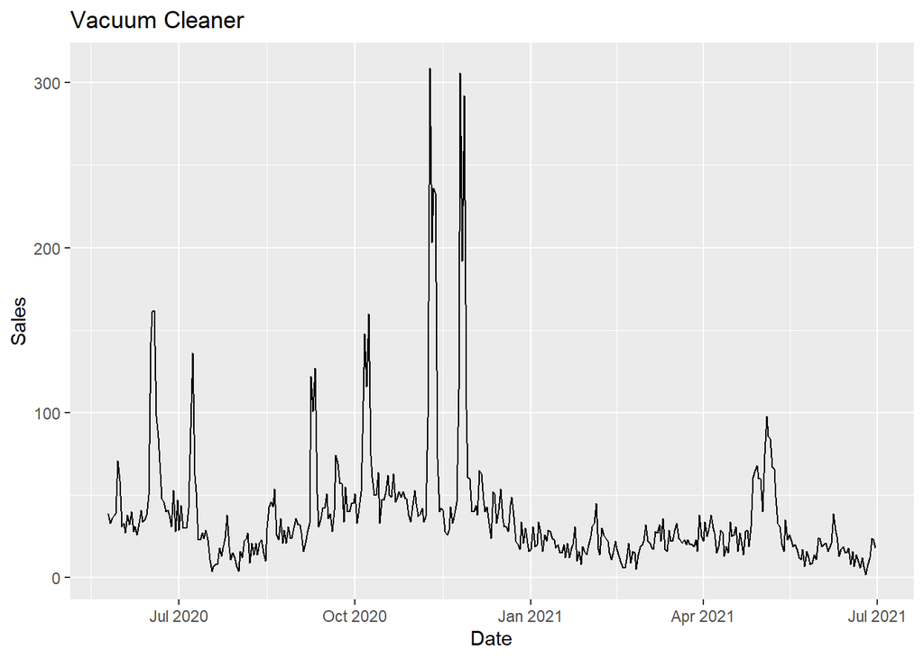

```r
ggplot(data_6, aes(x=event_date, y=sold_count)) + geom_line() + labs(title = "Vacuum Cleaner") + ylab("Sales") + xlab("Date")
```

Similarly, some of these points cannot be explained by seasonality or trend only, we may need other regressors.

Now, we decompose the series using `decomp()`.

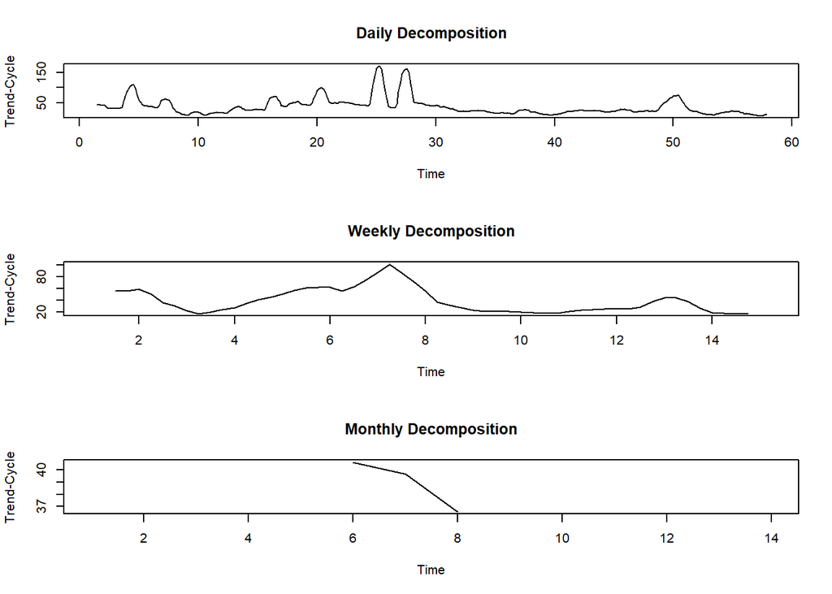

```r
dcmp_6 = decomp(data = data_6)
plotdcmp_trend(dcmp_6)
```

Again, weekly trend-cycle component smooths the series better. If we look at the weekly decomposition, we see a peak in the 7th month. Daily decomposition shows two peak points, probably due to discounts. From now on, we skip the discussion on the monthly decomposition.

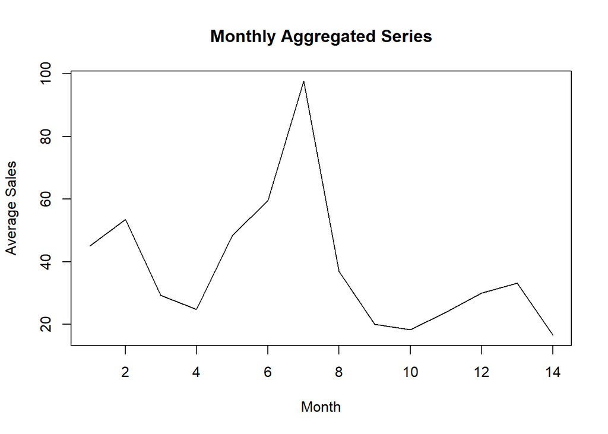

```r
plot(dcmp_6$monthly$aggregated, type="l", xlab="Month", ylab="Average Sales", main="Monthly Aggregated Series")
```

This is even smoother now. We can also check the seasonal components of the series.

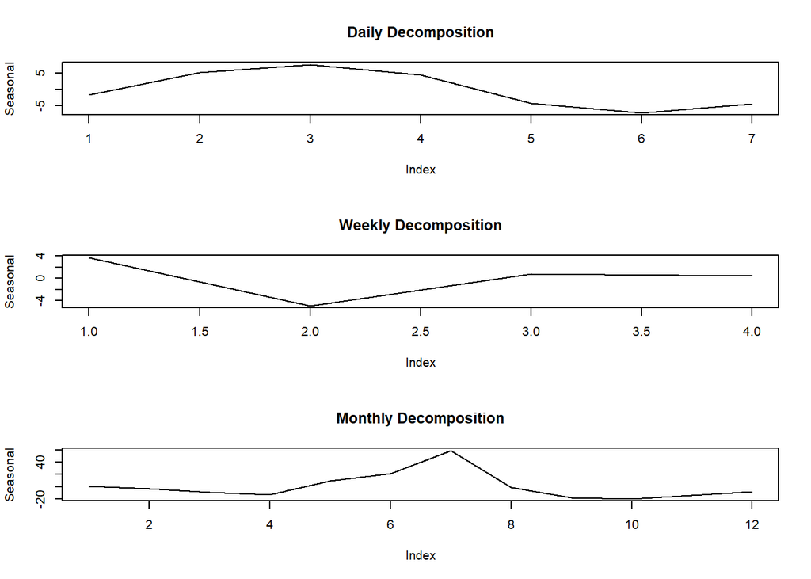

```r
plotdcmp_seasonal(dcmp_6)
```

We see that the second, the third, and the fourth days of the week, sales volume is larger but it is smaller especially on Saturday. In addition to this, sales volume is larger in the first week of the month, but this result is not so reliable as stated before. Monthly seasonality effect is not so reliable either because it is not an actual decomposition. But we see that sales volume is larger in the summer. Discussion on weekly and monthly decomposition will be skipped from now on, either.

At this point, we can try to model the random component of the daily decomposition with an ARIMA model. First we need to check the properties of the random component.

```r
random_6=dcmp_6$daily$random
data_6[,trend:=dcmp_6$daily$trend]
data_6[,seasonal:=dcmp_6$daily$seasonal]
data_6[,random:=random_6]
summary(ur.kpss(random_6))
```

```
##
## #######################
## # KPSS Unit Root Test #
## #######################
##
## Test is of type: mu with 5 lags.
##
## Value of test-statistic is: 0.0066
##
## Critical value for a significance level of:
##                 10pct  5pct 2.5pct  1pct
## critical values 0.347 0.463  0.574 0.739
```

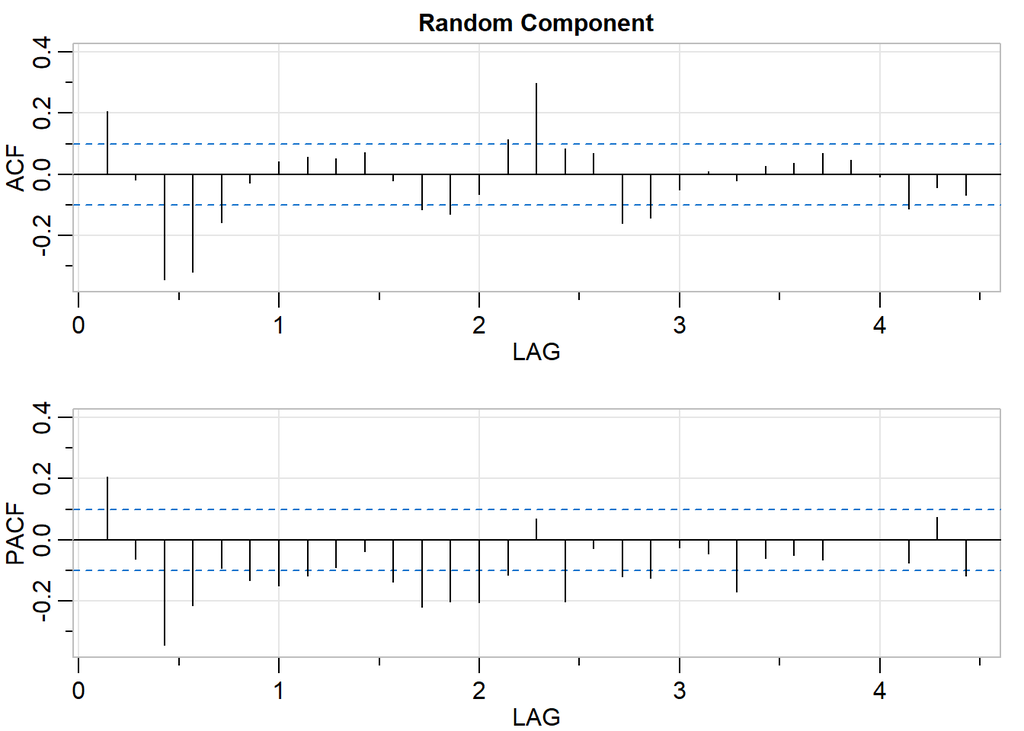

```
##      [,1]  [,2]  [,3]  [,4]  [,5]  [,6]  [,7]  [,8]  [,9] [,10] [,11] [,12]
## ACF  0.21 -0.02 -0.35 -0.32 -0.16 -0.03  0.04  0.06  0.05  0.07 -0.02 -0.12
## PACF 0.21 -0.06 -0.35 -0.22 -0.09 -0.13 -0.15 -0.12 -0.09 -0.04 -0.14 -0.22
##      [,13] [,14] [,15] [,16] [,17] [,18] [,19] [,20] [,21] [,22] [,23] [,24]
## ACF  -0.13 -0.07  0.11  0.30  0.08  0.07 -0.16 -0.14 -0.05  0.01 -0.02  0.03
## PACF -0.20 -0.20 -0.11  0.07 -0.20 -0.03 -0.12 -0.13 -0.03 -0.05 -0.17 -0.06
##      [,25] [,26] [,27] [,28] [,29] [,30] [,31]
## ACF   0.04  0.07  0.05 -0.01 -0.11 -0.04 -0.07
## PACF -0.05 -0.07  0.00  0.00 -0.08  0.07 -0.12
```

```r
acf2(random_6, main="Random Component")
```

It seems stationary and ACF and PACF suggest that there is some level of dependency among the observations. MA model is not suitable for this series but AR model may be suitable. We can try couple of models and compare them based on AIC values. Note that ACF and PACF is very similar to those of product 4 and product 5.

```r
ar_6_1=arima(random_6, order=c(3,0,0))
ar_6_2=arima(random_6, order=c(4,0,0))
ar_6_3=arima(random_6, order=c(5,0,0))
arma_6_1=arima(random_6, order=c(3,0,1))
arma_6_2=arima(random_6, order=c(4,0,1))
arma_6_3=arima(random_6, order=c(5,0,1))
c(ar1=AIC(ar_6_1), ar2=AIC(ar_6_2), ar3=AIC(ar_6_3), arma1=AIC(arma_6_1), arma2=AIC(arma_6_2), arma3=AIC(arma_6_3))
```

```
##      ar1      ar2      ar3    arma1    arma2    arma3
## 3412.361 3395.105 3393.737 3309.390 3311.222 3312.837
```

ARIMA(3,0,1) provides the best AIC value. We can check their performance on the training data.

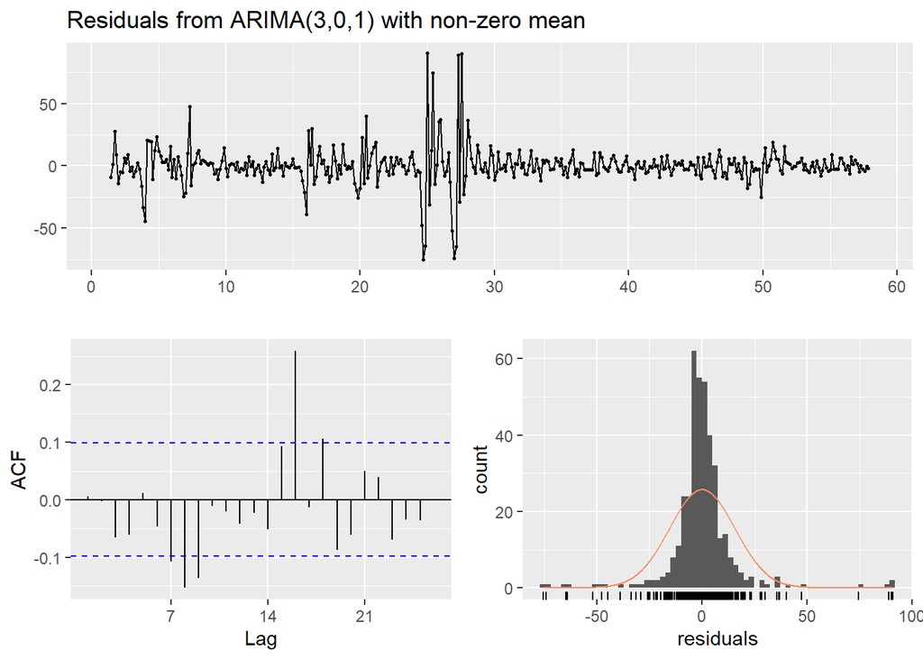

```
##
##  Ljung-Box test
##
## data:  Residuals from ARIMA(3,0,1) with non-zero mean
## Q* = 28.34, df = 9, p-value = 0.0008366
##
## Model df: 5.   Total lags used: 14
```

```r
checkresiduals(arma_6_1)
```

Assumptions are not strongly hold. Nevertheless, we cannot improve them at this point.

```r
data_6[,fitted_3_0:=random_6-ar_6_1$residuals+dcmp_6$daily$trend+dcmp_6$daily$seasonal]
data_6[,fitted_4_0:=random_6-ar_6_2$residuals+dcmp_6$daily$trend+dcmp_6$daily$seasonal]
data_6[,fitted_5_0:=random_6-ar_6_3$residuals+dcmp_6$daily$trend+dcmp_6$daily$seasonal]
data_6[,fitted_3_1:=random_6-arma_6_1$residuals+dcmp_6$daily$trend+dcmp_6$daily$seasonal]
data_6[,fitted_4_1:=random_6-arma_6_2$residuals+dcmp_6$daily$trend+dcmp_6$daily$seasonal]
data_6[,fitted_5_1:=random_6-arma_6_3$residuals+dcmp_6$daily$trend+dcmp_6$daily$seasonal]

melted_result=melt(data_6, c("event_date","sold_count"),
                   c("fitted_3_0","fitted_4_0", "fitted_5_0", "fitted_3_1",
                     "fitted_4_1","fitted_5_1"))

performance=melted_result[,accu_na(sold_count, value), by=list(variable)]
performance
```

```
##      variable   n     mean      sd       CV        FBias      MAPE     RMSE
## 1: fitted_3_0 396 38.13384 38.4934 1.009429 0.0005127085 0.2777643 17.75068
## 2: fitted_4_0 396 38.13384 38.4934 1.009429 0.0008471739 0.2734882 17.32002
## 3: fitted_5_0 396 38.13384 38.4934 1.009429 0.0008640951 0.2729656 17.24562
## 4: fitted_3_1 396 38.13384 38.4934 1.009429 0.0008659040 0.2541555 15.43564
## 5: fitted_4_1 396 38.13384 38.4934 1.009429 0.0008462059 0.2531817 15.43315
## 6: fitted_5_1 396 38.13384 38.4934 1.009429 0.0009536360 0.2538596 15.42434
##         MAD      MADP     WMAPE
## 1: 9.497636 0.2490606 0.2490606
## 2: 9.308463 0.2440998 0.2440998
## 3: 9.314425 0.2442562 0.2442562
## 4: 8.564559 0.2245921 0.2245921
## 5: 8.540418 0.2239590 0.2239590
## 6: 8.565072 0.2246056 0.2246056
```

As opposed to AIC values, ARIMA(4,0,1) gives the best result when comparing the models on the training set.

Now we can add some regressors to the model. Again note that these are lagged variables.

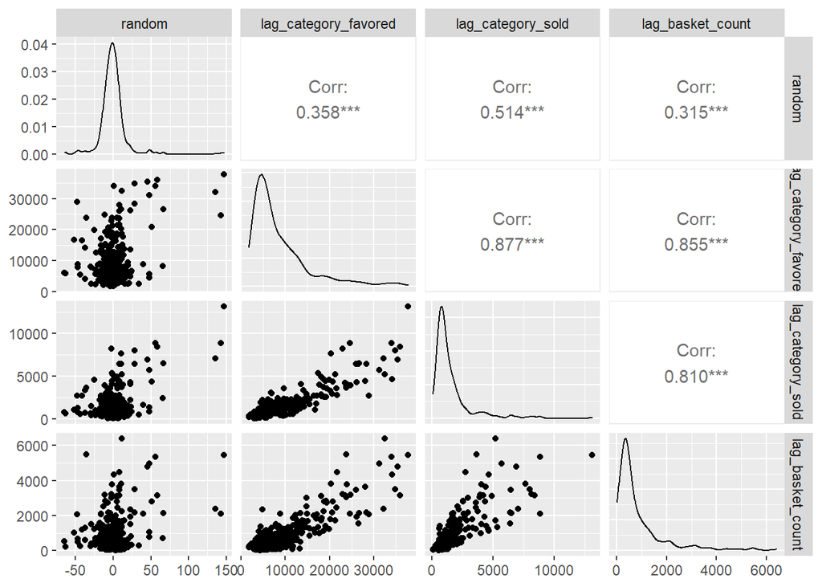

```r
ggpairs(data_6[,c("random","lag_category_favored","lag_category_sold","lag_basket_count")])
```

Now we try all three variables.

```r
lm_6=lm(random~lag_category_favored+lag_category_sold+lag_basket_count, data=data_6)
anova(lm_6)
```

```
## Analysis of Variance Table
##
## Response: random
##                       Df Sum Sq Mean Sq F value    Pr(>F)
## lag_category_favored   1  19089 19088.9 72.7576 3.233e-16 ***
## lag_category_sold      1  25701 25701.1 97.9599 < 2.2e-16 ***
## lag_basket_count       1   1086  1086.3  4.1406   0.04254 *
## Residuals            392 102846   262.4
## ---
## Signif. codes:  0 '***' 0.001 '**' 0.01 '*' 0.05 '.' 0.1 ' ' 1
```

We can update the linear model according to the anova table.

```r
lm_6=lm(random~lag_category_favored+lag_category_sold, data=data_6)
summary(lm_6)
```

```
##
## Call:
## lm(formula = random ~ lag_category_favored + lag_category_sold,
##     data = data_6)
##
## Residuals:
##     Min      1Q  Median      3Q     Max
## -59.610  -7.267   0.323   6.965 103.404
##
## Coefficients:
##                        Estimate Std. Error t value Pr(>|t|)
## (Intercept)          -6.1815486  1.3794110  -4.481 9.74e-06 ***
## lag_category_favored -0.0011562  0.0002541  -4.550 7.16e-06 ***
## lag_category_sold     0.0106949  0.0010849   9.858  < 2e-16 ***
## ---
## Signif. codes:  0 '***' 0.001 '**' 0.01 '*' 0.05 '.' 0.1 ' ' 1
##
## Residual standard error: 16.26 on 393 degrees of freedom
##   (6 observations deleted due to missingness)
## Multiple R-squared:  0.3012, Adjusted R-squared:  0.2976
## F-statistic: 84.68 on 2 and 393 DF,  p-value: < 2.2e-16
```

With two significant variables, a relatively large R-squared value is achieved.

Now we compare ARIMA(4,0,1) and the new ARIMAX model on the test period.

```r
results=vector('list',length(test_dates))
for(i in 1:length(test_dates)){
  current_date=test_dates[i]-forecast_ahead

  past_data=data_6[event_date<=current_date]
  forecast_data=data_6[event_date==test_dates[i]]

  # arima model
  frcst=arima(past_data[,ts(random)], order=c(4,0,1))
  frcst=forecast(frcst, h=forecast_ahead)
  forecast_data[,arima_prediction:=round(frcst$mean[2]+as.numeric(trend)+as.numeric(seasonal), 0)]

  # arimax model
  reg = matrix(c(past_data[,lag_category_favored], past_data[,lag_category_sold]), ncol=2)
  frcst=auto.arima(past_data[,ts(random)],max.p=4,start.p=4,max.q=1,start.q=1,xreg=reg,seasonal=FALSE,stepwise=FALSE,approximation=FALSE)
  reg = matrix(c(past_data[(.N-1):.N, category_favored], past_data[(.N-1):.N, category_sold]), ncol=2)
  frcst=forecast(frcst, h=forecast_ahead, xreg=reg)
  forecast_data[,arimax_prediction:=round(frcst$mean[2]+as.numeric(trend)+as.numeric(seasonal), 0)]

  results[[i]]=forecast_data
}
overall_results=rbindlist(results)
melted_result=melt(overall_results,c('event_date','sold_count'),
                   c('arima_prediction','arimax_prediction'))
performance= melted_result[,accu(sold_count,value),by=list(variable)]
performance
```

```
##             variable n     mean      sd        CV      FBias      MAPE     RMSE
## 1:  arima_prediction 7 8.142857 3.57904 0.4395312 -0.2105263 0.5159864 2.828427
## 2: arimax_prediction 7 8.142857 3.57904 0.4395312 -0.6140351 1.2108844 6.380775
##         MAD      MADP     WMAPE
## 1: 2.285714 0.2807018 0.2807018
## 2: 5.000000 0.6140351 0.6140351
```

ARIMAX is significantly worse than ARIMA model. Adding two regressors did not help.

## Product 7

The plot of the series is shown below.

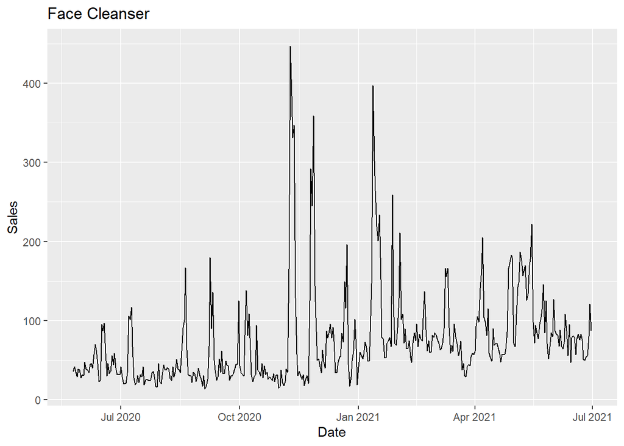

```r
ggplot(data_7, aes(x=event_date, y=sold_count)) + geom_line() + labs(title = "Face Cleanser") + ylab("Sales") + xlab("Date")
```

Some of these points cannot be explained by seasonality or trend only, we may need other regressors.

Now, we decompose the series.

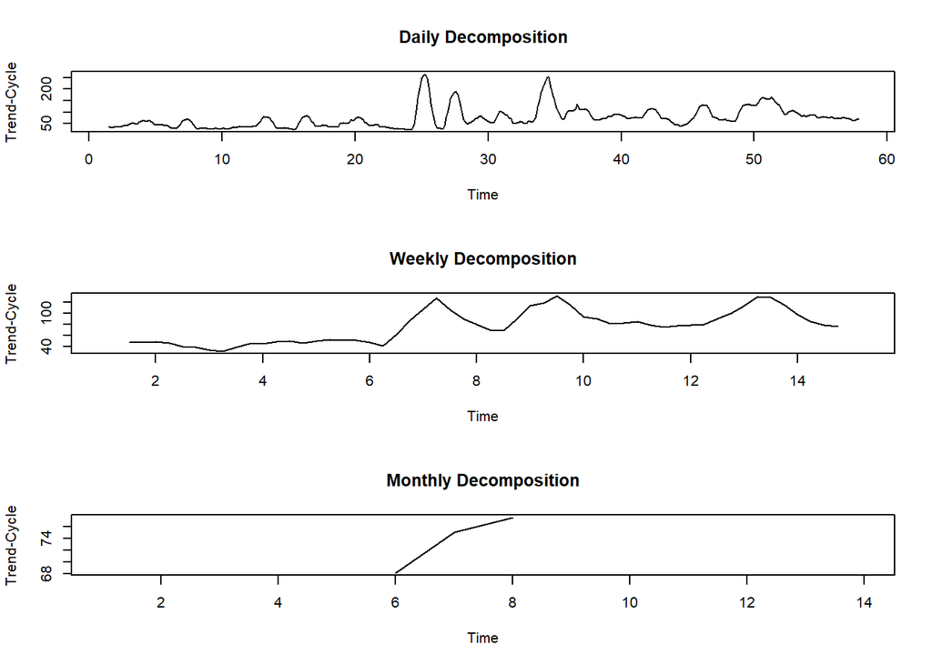

```r
dcmp_7 = decomp(data = data_7)
plotdcmp_trend(dcmp_7)
```

Similarly, weekly decomposition provides smoother trend-cycle curve. Weekly decomposition suggests that there is an increase in the level after the 6th month. Also we see some peak points. Now we check the monthly aggregated data.

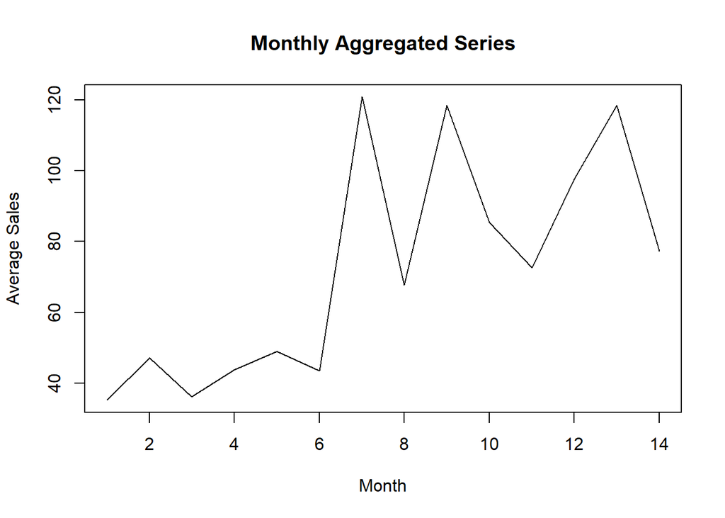

```r
plot(dcmp_7$monthly$aggregated, type="l", xlab="Month", ylab="Average Sales", main="Monthly Aggregated Series")
```

This is even smoother now. We can also check the seasonal components of the series.

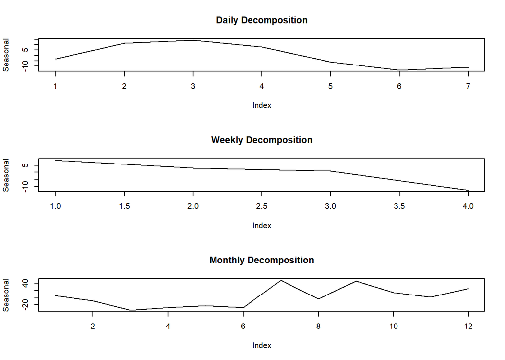

```r
plotdcmp_seasonal(dcmp_7)
```

We see that the second, the third, and the fourth days of the week, sales volume is larger but now y scale is shorter. In addition to this, sales volume is larger in the first week of the month and linearly decreasing over time. Sales volume tends to increase in the summer and the fall.

At this point, we can try to model the random component of the daily decomposition with an ARIMA model. First we need to check the properties of the random component.

```r
random_7=dcmp_7$daily$random
data_7[,trend:=dcmp_7$daily$trend]
data_7[,seasonal:=dcmp_7$daily$seasonal]
data_7[,random:=random_7]
summary(ur.kpss(random_7))
```

```
##
## #######################
## # KPSS Unit Root Test #
## #######################
##
## Test is of type: mu with 5 lags.
##
## Value of test-statistic is: 0.0066
##
## Critical value for a significance level of:
##                 10pct  5pct 2.5pct  1pct
## critical values 0.347 0.463  0.574 0.739
```

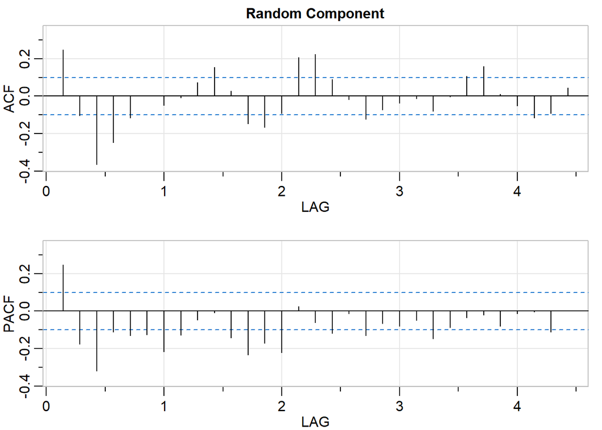

```
##      [,1]  [,2]  [,3]  [,4]  [,5]  [,6]  [,7]  [,8]  [,9] [,10] [,11] [,12]
## ACF  0.25 -0.11 -0.37 -0.25 -0.12  0.00 -0.05 -0.01  0.07  0.15  0.03 -0.15
## PACF 0.25 -0.18 -0.32 -0.11 -0.13 -0.13 -0.22 -0.13 -0.05 -0.01 -0.14 -0.23
##      [,13] [,14] [,15] [,16] [,17] [,18] [,19] [,20] [,21] [,22] [,23] [,24]
## ACF  -0.17 -0.09  0.21  0.22  0.09 -0.02 -0.12 -0.07 -0.04 -0.01 -0.08  0.00
## PACF -0.17 -0.22  0.03 -0.06 -0.12 -0.01 -0.13 -0.07 -0.08 -0.05 -0.15 -0.09
##      [,25] [,26] [,27] [,28] [,29] [,30] [,31]
## ACF   0.11  0.16  0.01 -0.05 -0.12 -0.09  0.04
## PACF -0.03 -0.02 -0.08 -0.01  0.00 -0.11  0.00
```

```r
acf2(random_7, main="Random Component")
```

It can be assumed stationary and ACF and PACF suggest that there is some level of dependency among the observations. We can try couple of models and compare them based on AIC values. Note that ACF and PACF is very similar to those of the other products.

```r
ar_7_1=arima(random_7, order=c(3,0,0))
ar_7_2=arima(random_7, order=c(4,0,0))
ar_7_3=arima(random_7, order=c(5,0,0))
arma_7_1=arima(random_7, order=c(3,0,1))
arma_7_2=arima(random_7, order=c(4,0,1))
arma_7_3=arima(random_7, order=c(5,0,1))
c(ar1=AIC(ar_7_1), ar2=AIC(ar_7_2), ar3=AIC(ar_7_3), arma1=AIC(arma_7_1), arma2=AIC(arma_7_2), arma3=AIC(arma_7_3))
```

```
##      ar1      ar2      ar3    arma1    arma2    arma3
## 3798.045 3795.119 3790.439 3708.627 3710.144 3705.108
```

ARIMA(5,0,1) provides the best AIC value. We can check their performance on the training data.

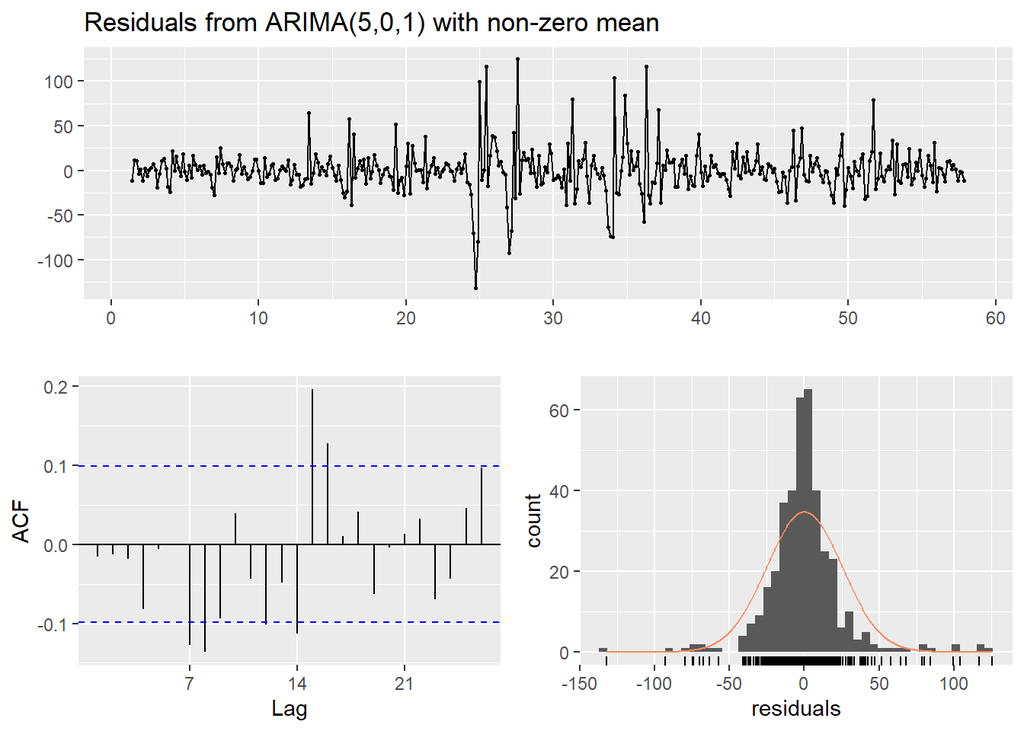

```
##
##  Ljung-Box test
##
## data:  Residuals from ARIMA(5,0,1) with non-zero mean
## Q* = 32.605, df = 7, p-value = 3.135e-05
##
## Model df: 7.   Total lags used: 14
```

```r
checkresiduals(arma_7_3)
```

Assumptions are not strongly hold. But we can move on.

```r
data_7[,fitted_3_0:=random_7-ar_7_1$residuals+dcmp_7$daily$trend+dcmp_7$daily$seasonal]
data_7[,fitted_4_0:=random_7-ar_7_2$residuals+dcmp_7$daily$trend+dcmp_7$daily$seasonal]
data_7[,fitted_5_0:=random_7-ar_7_3$residuals+dcmp_7$daily$trend+dcmp_7$daily$seasonal]
data_7[,fitted_3_1:=random_7-arma_7_1$residuals+dcmp_7$daily$trend+dcmp_7$daily$seasonal]
data_7[,fitted_4_1:=random_7-arma_7_2$residuals+dcmp_7$daily$trend+dcmp_7$daily$seasonal]
data_7[,fitted_5_1:=random_7-arma_7_3$residuals+dcmp_7$daily$trend+dcmp_7$daily$seasonal]

melted_result=melt(data_7, c("event_date","sold_count"),
                   c("fitted_3_0","fitted_4_0", "fitted_5_0", "fitted_3_1",
                     "fitted_4_1","fitted_5_1"))

performance=melted_result[,accu_na(sold_count, value), by=list(variable)]
performance
```

```
##      variable   n     mean       sd        CV         FBias      MAPE     RMSE
## 1: fitted_3_0 396 74.54798 61.34654 0.8229135  1.884774e-04 0.2937091 28.88674
## 2: fitted_4_0 396 74.54798 61.34654 0.8229135  2.009726e-04 0.2923259 28.70586
## 3: fitted_5_0 396 74.54798 61.34654 0.8229135  2.152121e-04 0.2894617 28.46176
## 4: fitted_3_1 396 74.54798 61.34654 0.8229135 -8.650274e-05 0.2628885 25.56014
## 5: fitted_4_1 396 74.54798 61.34654 0.8229135 -7.657827e-06 0.2626759 25.54680
## 6: fitted_5_1 396 74.54798 61.34654 0.8229135 -2.062748e-05 0.2623584 25.30974
##         MAD      MADP     WMAPE
## 1: 18.14299 0.2433733 0.2433733
## 2: 18.02555 0.2417979 0.2417979
## 3: 17.75318 0.2381443 0.2381443
## 4: 16.00022 0.2146299 0.2146299
## 5: 15.96904 0.2142116 0.2142116
## 6: 15.91951 0.2135472 0.2135472
```

We see that ARIMA(5,0,1) gives the best result.

Now we can add some regressors to the model. Again note that these are lagged variables.

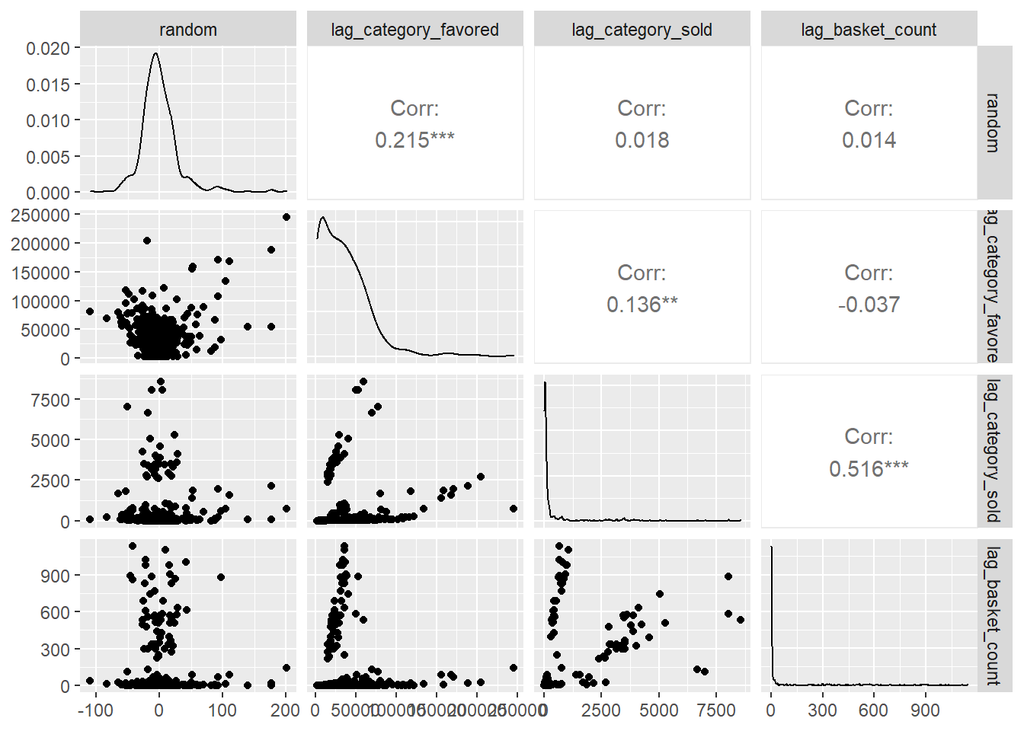

```r
ggpairs(data_7[,c("random","lag_category_favored","lag_category_sold","lag_basket_count")])
```

`lag_category_favored` seems to be the most important one.

```r
lm_7=lm(random~lag_category_favored, data=data_7)
summary(lm_7)
```

```
##
## Call:
## lm(formula = random ~ lag_category_favored, data = data_7)
##
## Residuals:
##      Min       1Q   Median       3Q      Max
## -119.257  -15.665   -1.624   13.485  172.514
##
## Coefficients:
##                        Estimate Std. Error t value Pr(>|t|)
## (Intercept)          -7.633e+00  2.347e+00  -3.253  0.00124 **
## lag_category_favored  2.097e-04  4.807e-05   4.363 1.64e-05 ***
## ---
## Signif. codes:  0 '***' 0.001 '**' 0.01 '*' 0.05 '.' 0.1 ' ' 1
##
## Residual standard error: 31.32 on 394 degrees of freedom
##   (6 observations deleted due to missingness)
## Multiple R-squared:  0.04608,    Adjusted R-squared:  0.04366
## F-statistic: 19.03 on 1 and 394 DF,  p-value: 1.642e-05
```

The relationship is very significant.

Now we compare ARIMA(5,0,1) and the new ARIMAX model on the test period.

```r
results=vector('list',length(test_dates))
for(i in 1:length(test_dates)){
  current_date=test_dates[i]-forecast_ahead

  past_data=data_7[event_date<=current_date]
  forecast_data=data_7[event_date==test_dates[i]]

  # arima model
  frcst=arima(past_data[,ts(random)], order=c(5,0,1))
  frcst=forecast(frcst, h=forecast_ahead)
  forecast_data[,arima_prediction:=round(frcst$mean[2]+as.numeric(trend)+as.numeric(seasonal), 0)]

  # arimax model
  reg = matrix(past_data[,lag_category_favored], ncol=1)
  frcst=auto.arima(past_data[,ts(random)],max.p=5,start.p=5,max.q=1,start.q=1,xreg=reg,seasonal=FALSE,stepwise=FALSE,approximation=FALSE)
  reg = matrix(past_data[(.N-1):.N, category_favored], ncol=1)
  frcst=forecast(frcst, h=forecast_ahead, xreg=reg)
  forecast_data[,arimax_prediction:=round(frcst$mean[2]+as.numeric(trend)+as.numeric(seasonal), 0)]

  results[[i]]=forecast_data
}
overall_results=rbindlist(results)
melted_result=melt(overall_results,c('event_date','sold_count'),
                   c('arima_prediction','arimax_prediction'))
performance= melted_result[,accu(sold_count,value),by=list(variable)]
performance
```

```
##             variable n     mean       sd        CV       FBias      MAPE
## 1:  arima_prediction 7 63.57143 13.86671 0.2181281 -0.04044944 0.0839343
## 2: arimax_prediction 7 63.57143 13.86671 0.2181281 -0.01348315 0.1120626
##        RMSE      MAD       MADP      WMAPE
## 1: 6.633250 4.857143 0.07640449 0.07640449
## 2: 7.578164 6.857143 0.10786517 0.10786517
```

ARIMA model provides better results again. If we are to build a forecast model, we would build ARIMA(5,0,1). Nevertheless, ARIMAX model provides smaller bias.

## Product 8

The plot of the series is shown below.

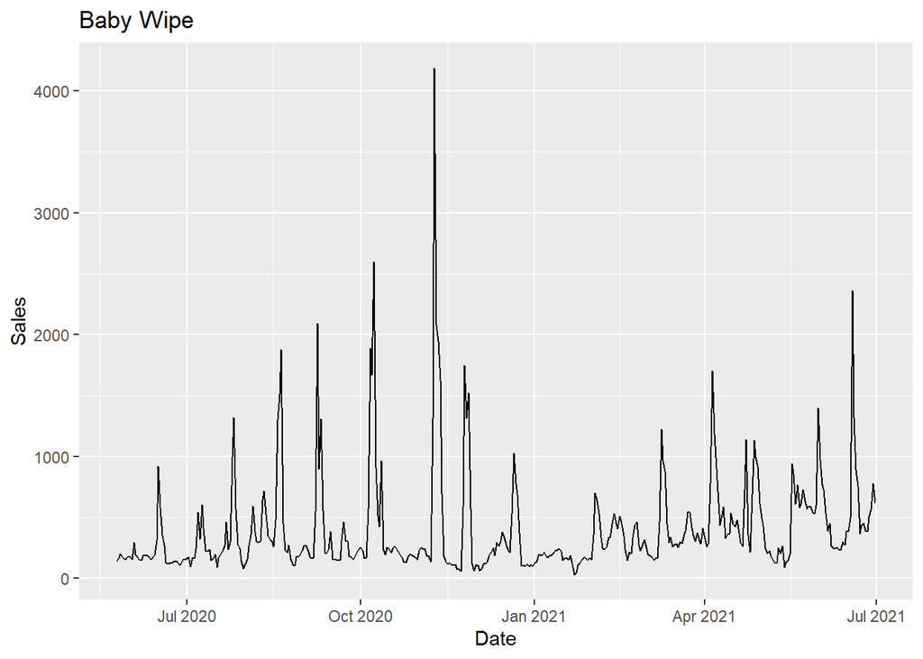

```r
ggplot(data_8, aes(x=event_date, y=sold_count)) + geom_line() + labs(title = "Baby Wipe") + ylab("Sales") + xlab("Date")
```

Some of these points cannot be explained by seasonality or trend only, we may need other regressors.

Now, we decompose the series.

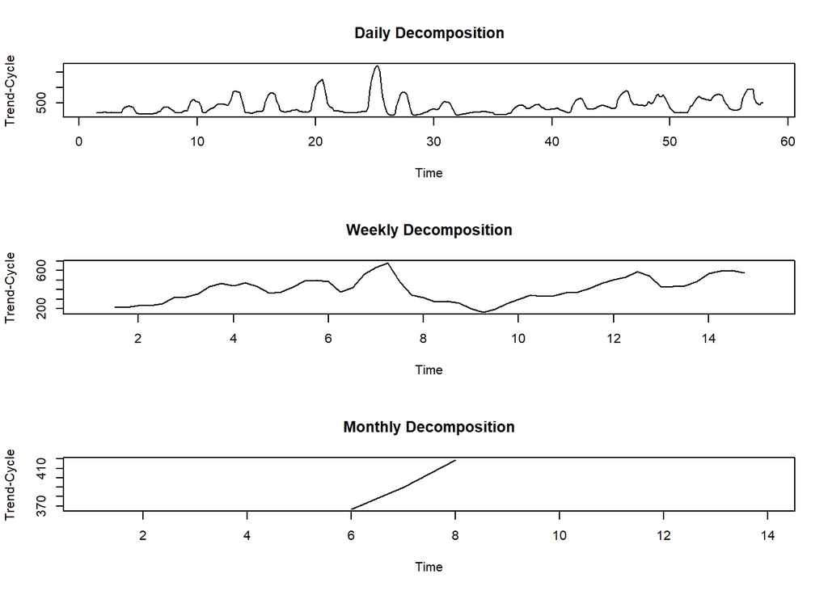

```r
dcmp_8 = decomp(data = data_8)
plotdcmp_trend(dcmp_8)
```

We can see that weekly trend-cycle component smoothes the series better. There is also a sharp decrease in the 7th month and the sales starts increasing slightly after the 9th month. We can also check monthly aggregated data.

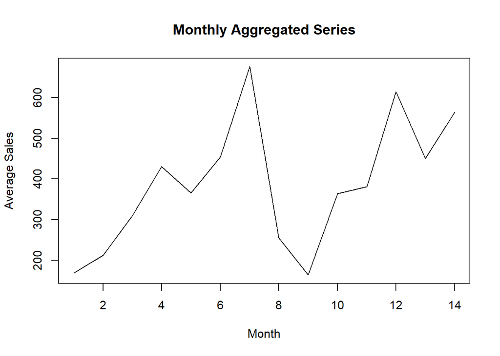

```r
plot(dcmp_8$monthly$aggregated, type="l", xlab="Month", ylab="Average Sales", main="Monthly Aggregated Series")
```

This is even smoother now. We can also check the seasonal components of the series.

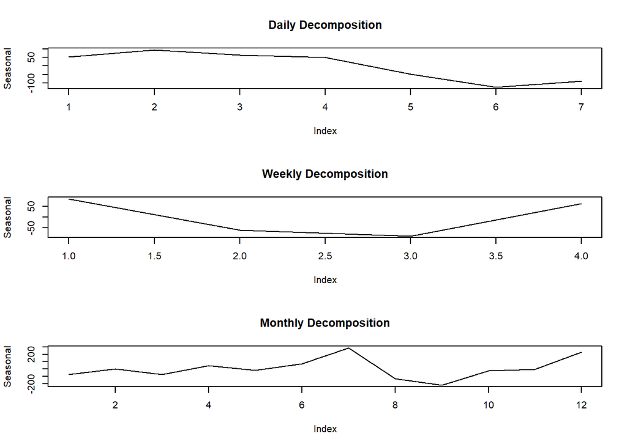

```r
plotdcmp_seasonal(dcmp_8)
```

We see that sales volume is larger on the first and the second days of the week. In addition to this, sales volume is larger in the first week and the last week of the month, as opposed to the second and the third weeks. Lastly, we see that sales volume is larger in July and December. It is significantly lower in September.

At this point, we can try to model the random component of the daily decomposition with an ARIMA model. First we need to check the properties of the random component.

```r
random_8=dcmp_8$daily$random
data_8[,trend:=dcmp_8$daily$trend]
data_8[,seasonal:=dcmp_8$daily$seasonal]
data_8[,random:=random_8]
summary(ur.kpss(random_8))
```

```
##
## #######################
## # KPSS Unit Root Test #
## #######################
##
## Test is of type: mu with 5 lags.
##
## Value of test-statistic is: 0.0063
##
## Critical value for a significance level of:
##                 10pct  5pct 2.5pct  1pct
## critical values 0.347 0.463  0.574 0.739
```

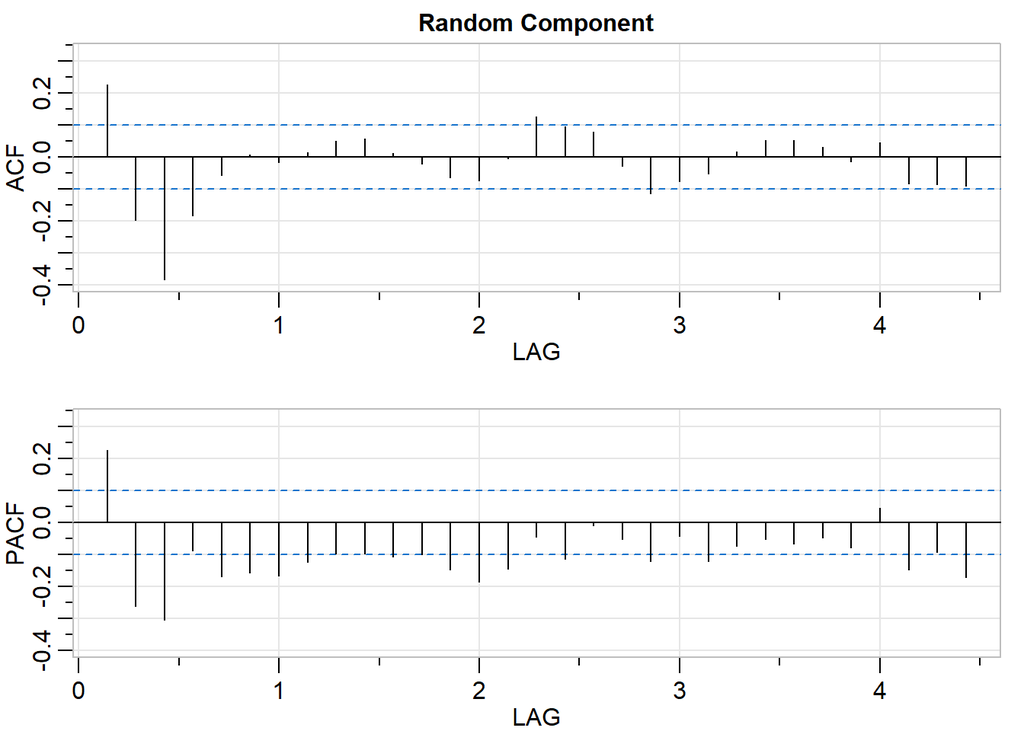

```
##      [,1]  [,2]  [,3]  [,4]  [,5]  [,6]  [,7]  [,8]  [,9] [,10] [,11] [,12]
## ACF  0.22 -0.20 -0.38 -0.18 -0.06  0.01 -0.02  0.02  0.05  0.06  0.01 -0.02
## PACF 0.22 -0.26 -0.30 -0.09 -0.17 -0.16 -0.17 -0.12 -0.10 -0.10 -0.11 -0.10
##      [,13] [,14] [,15] [,16] [,17] [,18] [,19] [,20] [,21] [,22] [,23] [,24]
## ACF  -0.06 -0.07  0.00  0.13  0.10  0.08 -0.03 -0.11 -0.08 -0.05  0.02  0.05
## PACF -0.15 -0.19 -0.14 -0.04 -0.11 -0.01 -0.05 -0.12 -0.04 -0.12 -0.07 -0.05
##      [,25] [,26] [,27] [,28] [,29] [,30] [,31]
## ACF   0.05  0.03 -0.01  0.04 -0.08 -0.08 -0.09
## PACF -0.07 -0.05 -0.08  0.05 -0.15 -0.09 -0.17
```

```r
acf2(random_8, main="Random Component")
```

The series is stationary but this time we need a more complicated ARIMA model. AR(p) or MA(q) may not be enough.

```r
ar_8_1=arima(random_8, order=c(2,0,0))
ar_8_2=arima(random_8, order=c(3,0,0))
ma_8_1=arima(random_8, order=c(0,0,3))
ma_8_2=arima(random_8, order=c(0,0,4))
arma_8_1=arima(random_8, order=c(2,0,3))
arma_8_2=arima(random_8, order=c(2,0,4))
arma_8_3=arima(random_8, order=c(3,0,3))
arma_8_4=arima(random_8, order=c(3,0,4))
c(ar1=AIC(ar_8_1), ar2=AIC(ar_8_2), ma1=AIC(ma_8_1), ma2=AIC(ma_8_2), arma1=AIC(arma_8_1), arma2=AIC(arma_8_2), arma3=AIC(arma_8_3), arma4=AIC(arma_8_4))
```

```
##      ar1      ar2      ma1      ma2    arma1    arma2    arma3    arma4
## 5496.679 5460.725 5385.676 5383.329 5337.884 5327.087 5370.066 5328.951
```

ARIMA(2,0,4) provides the best AIC value. We can check their performance on the training data.

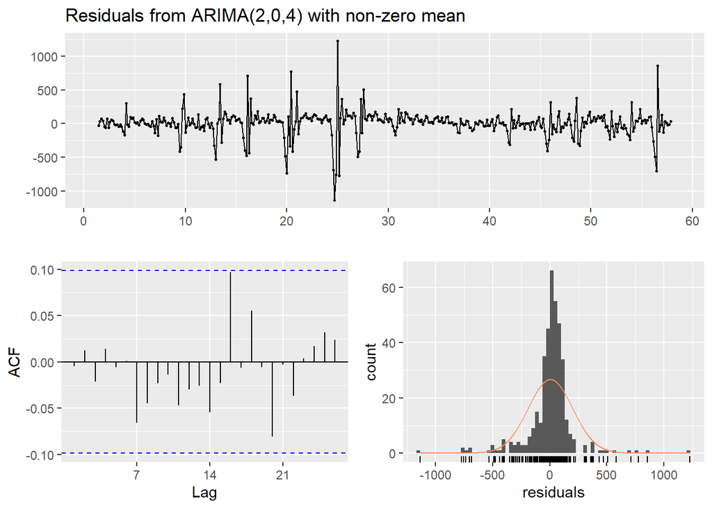

```
##
##  Ljung-Box test
##
## data:  Residuals from ARIMA(2,0,4) with non-zero mean
## Q* = 5.9751, df = 7, p-value = 0.5427
##
## Model df: 7.   Total lags used: 14
```

```r
checkresiduals(arma_8_2)
```

Assumptions on residuals seem to hold somehow.

```r
data_8[,fitted_2_0:=random_8-ar_8_1$residuals+dcmp_8$daily$trend+dcmp_8$daily$seasonal]
data_8[,fitted_3_0:=random_8-ar_8_2$residuals+dcmp_8$daily$trend+dcmp_8$daily$seasonal]
data_8[,fitted_0_3:=random_8-ma_8_1$residuals+dcmp_8$daily$trend+dcmp_8$daily$seasonal]
data_8[,fitted_0_4:=random_8-ma_8_1$residuals+dcmp_8$daily$trend+dcmp_8$daily$seasonal]
data_8[,fitted_2_3:=random_8-arma_8_1$residuals+dcmp_8$daily$trend+dcmp_8$daily$seasonal]
data_8[,fitted_2_4:=random_8-arma_8_2$residuals+dcmp_8$daily$trend+dcmp_8$daily$seasonal]
data_8[,fitted_3_3:=random_8-arma_8_3$residuals+dcmp_8$daily$trend+dcmp_8$daily$seasonal]
data_8[,fitted_3_4:=random_8-arma_8_4$residuals+dcmp_8$daily$trend+dcmp_8$daily$seasonal]

melted_result=melt(data_8, c("event_date","sold_count"),
                   c("fitted_2_0","fitted_3_0", "fitted_0_3", "fitted_0_4",
                     "fitted_2_3","fitted_2_4", "fitted_3_3", "fitted_3_4"))

performance=melted_result[,accu_na(sold_count, value), by=list(variable)]
performance
```

```
##      variable   n     mean       sd       CV        FBias      MAPE     RMSE
## 1: fitted_2_0 396 398.3409 426.7404 1.071294 3.346865e-05 0.4223306 247.3911
## 2: fitted_3_0 396 398.3409 426.7404 1.071294 1.853274e-04 0.4307906 235.7306
## 3: fitted_0_3 396 398.3409 426.7404 1.071294 1.959736e-03 0.3853510 213.1323
## 4: fitted_0_4 396 398.3409 426.7404 1.071294 1.959736e-03 0.3853510 213.1323
## 5: fitted_2_3 396 398.3409 426.7404 1.071294 1.244965e-02 0.4194468 198.1175
## 6: fitted_2_4 396 398.3409 426.7404 1.071294 9.768285e-03 0.4130231 195.2094
## 7: fitted_3_3 396 398.3409 426.7404 1.071294 1.542953e-03 0.3910711 207.2054
## 8: fitted_3_4 396 398.3409 426.7404 1.071294 1.467406e-02 0.4164082 195.0684
##         MAD      MADP     WMAPE
## 1: 131.5485 0.3302410 0.3302410
## 2: 128.3615 0.3222402 0.3222402
## 3: 116.4387 0.2923093 0.2923093
## 4: 116.4387 0.2923093 0.2923093
## 5: 114.9136 0.2884806 0.2884806
## 6: 113.8749 0.2858729 0.2858729
## 7: 114.7553 0.2880831 0.2880831
## 8: 114.7611 0.2880976 0.2880976
```

ARIMA(2,0,4) gives the best result.

Now we can add some regressors to the model. Again note that these are lagged variables.

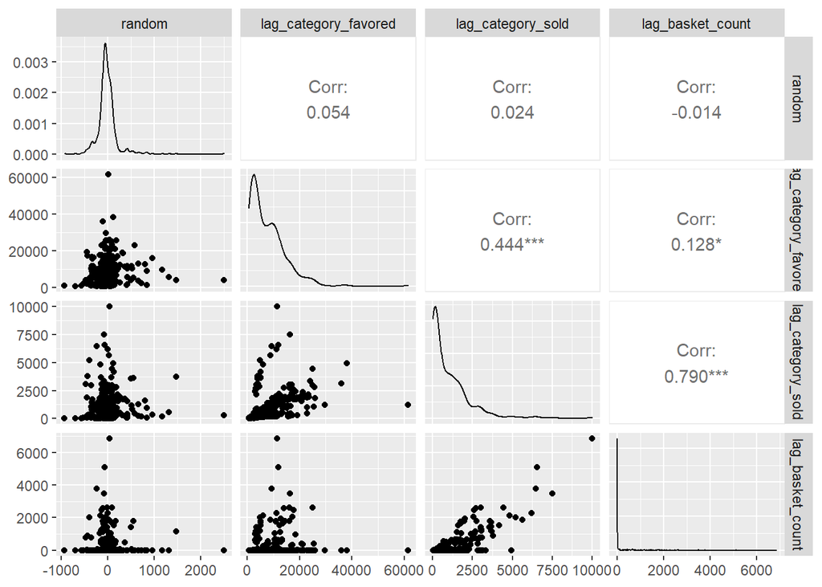

```r
ggpairs(data_8[,c("random","lag_category_favored","lag_category_sold","lag_basket_count")])
```

```r
results=vector('list',length(test_dates))
for(i in 1:length(test_dates)){
  current_date=test_dates[i]-forecast_ahead

  past_data=data_5[event_date<=current_date]
  forecast_data=data_5[event_date==test_dates[i]]

  # arima model
  frcst=arima(past_data[,ts(random)], order=c(2,0,4))
  frcst=forecast(frcst, h=forecast_ahead)
  forecast_data[,arima_prediction:=round(frcst$mean[2]+as.numeric(trend)+as.numeric(seasonal), 0)]

  results[[i]]=forecast_data
}
overall_results=rbindlist(results)
melted_result=melt(overall_results,c('event_date','sold_count'),
                   'arima_prediction')
performance= melted_result[,accu(sold_count,value),by=list(variable)]
performance
```

[output not shown]

We cannot reach a conclusion without comparing this with another model.

## Product 9

The plot of the series is shown below.

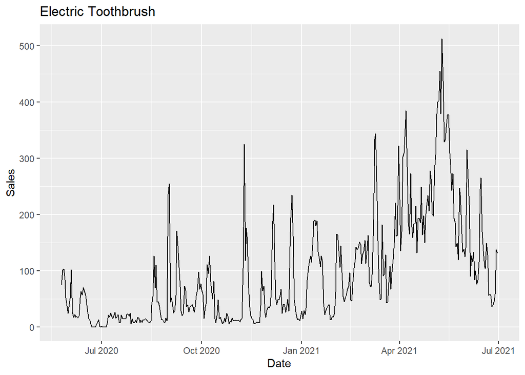

```r
ggplot(data_9, aes(x=event_date, y=sold_count)) + geom_line() + labs(title = "Electric Toothbrush") + ylab("Sales") + xlab("Date")
```

Similar to the previous products, some of these points cannot be explained by seasonality or trend only, we may need other regressors.

Now, we decompose the series using function `decomp()`.

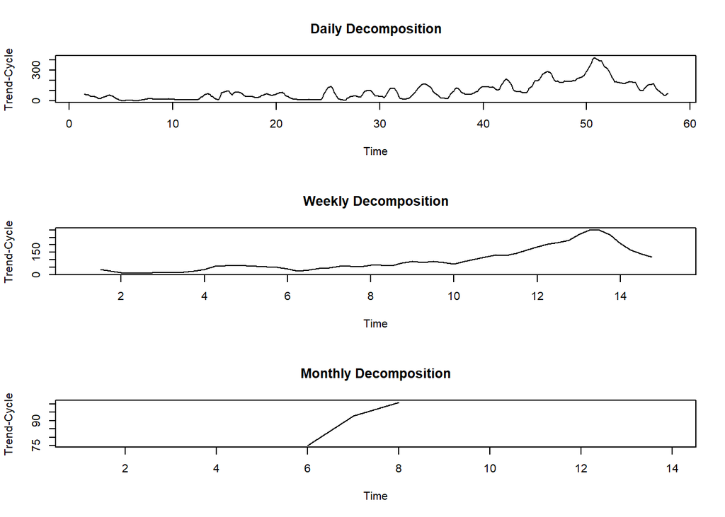

```r
dcmp_9 = decomp(data = data_9)
plotdcmp_trend(dcmp_9)
```

Weekly decomposition provides smoother curve. Sales is slightly increasing over time but it starts decreasing in the 13th month. The monthly aggregated data looks like this:

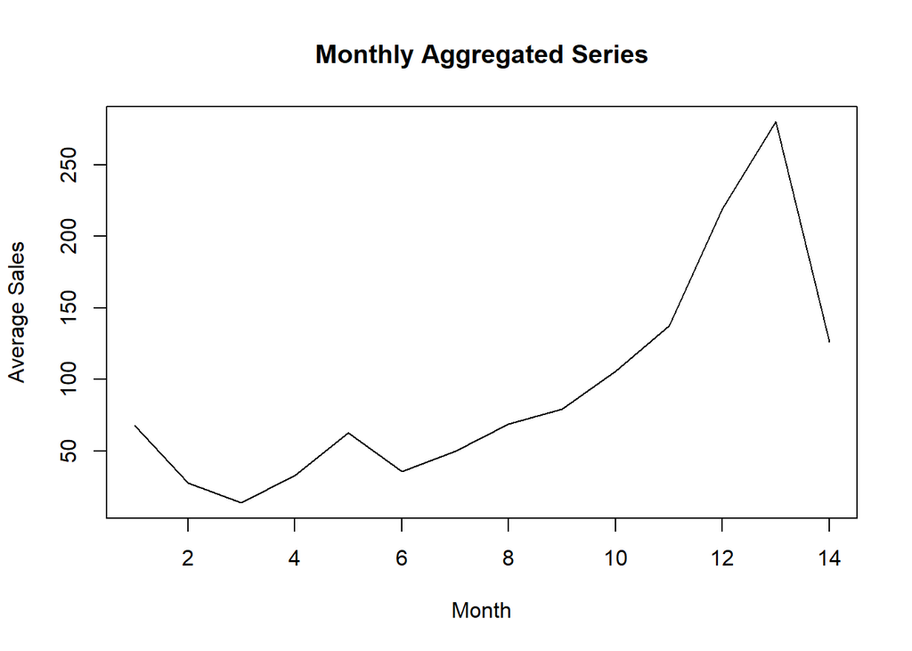

```r
plot(dcmp_9$monthly$aggregated, type="l", xlab="Month", ylab="Average Sales", main="Monthly Aggregated Series")
```

Monthly aggregated data is even smoother. We can also check the seasonal components of the series.

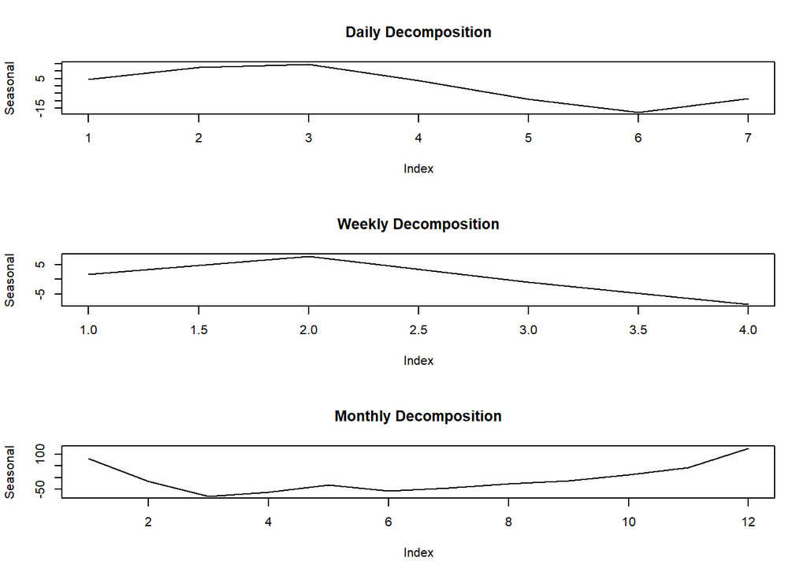

```r
plotdcmp_seasonal(dcmp_9)
```

In general, the largest sales volumes are observed on day 2 and 3 of the week which corresponds to Tuesday and Wednesday. On the other hand, the smallest sales volume is observed on Saturday, generally. Weekly decomposition is not trustable as discussed earlier, but it shows approximately how the week of the month affects the sales. The second week of the month has the largest sales and the fourth week has the smallest. Lastly, the sales volume tends to be larger in December and January. It is smaller in the spring and the summer, especially in March.

At this point, we can try to model the random component of the daily decomposition with an ARIMA model. First we need to check the properties of the random component.

```r
random_9=dcmp_9$daily$random
data_9[,trend:=dcmp_9$daily$trend]
data_9[,seasonal:=dcmp_9$daily$seasonal]
data_9[,random:=random_9]
summary(ur.kpss(random_9))
```

```
##
## #######################
## # KPSS Unit Root Test #
## #######################
##
## Test is of type: mu with 5 lags.
##
## Value of test-statistic is: 0.0077
##
## Critical value for a significance level of:
##                 10pct  5pct 2.5pct  1pct
## critical values 0.347 0.463  0.574 0.739
```

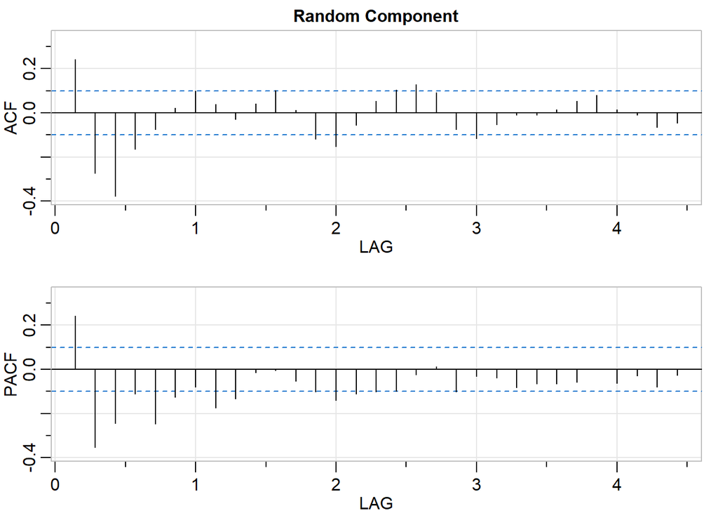

```
##      [,1]  [,2]  [,3]  [,4]  [,5]  [,6]  [,7]  [,8]  [,9] [,10] [,11] [,12]
## ACF  0.24 -0.27 -0.38 -0.16 -0.08  0.02  0.10  0.04 -0.03  0.04   0.1  0.01
## PACF 0.24 -0.35 -0.25 -0.11 -0.25 -0.12 -0.08 -0.17 -0.13 -0.02   0.0 -0.05
##      [,13] [,14] [,15] [,16] [,17] [,18] [,19] [,20] [,21] [,22] [,23] [,24]
## ACF  -0.12 -0.15 -0.06  0.05   0.1  0.13  0.09 -0.07 -0.12 -0.05 -0.01 -0.01
## PACF -0.10 -0.14 -0.11 -0.10  -0.1 -0.02  0.01 -0.10 -0.03 -0.04 -0.08 -0.07
##      [,25] [,26] [,27] [,28] [,29] [,30] [,31]
## ACF   0.01  0.05  0.08  0.02 -0.01 -0.07 -0.05
## PACF -0.06 -0.06  0.00 -0.06 -0.03 -0.08 -0.03
```

```r
acf2(random_9, main="Random Component")
```

It can be assumed stationary and ACF and PACF suggest that there is some level of dependency among the observations. ACF and PACF are similar to products 4,5, and 6. Thus, we try to same ARIMA models.

```r
ar_9_1=arima(random_9, order=c(3,0,0))
ar_9_2=arima(random_9, order=c(4,0,0))
ar_9_3=arima(random_9, order=c(5,0,0))
arma_9_1=arima(random_9, order=c(3,0,1))
arma_9_2=arima(random_9, order=c(4,0,1))
arma_9_3=arima(random_9, order=c(5,0,1))
c(ar1=AIC(ar_9_1), ar2=AIC(ar_9_2), ar3=AIC(ar_9_3), arma1=AIC(arma_9_1), arma2=AIC(arma_9_2), arma3=AIC(arma_9_3))
```

```
##      ar1      ar2      ar3    arma1    arma2    arma3
## 3867.755 3864.696 3841.936 3779.989 3781.843 3777.544
```

ARIMA(5,0,1) provides the best AIC value. We can check their performance on the training data.

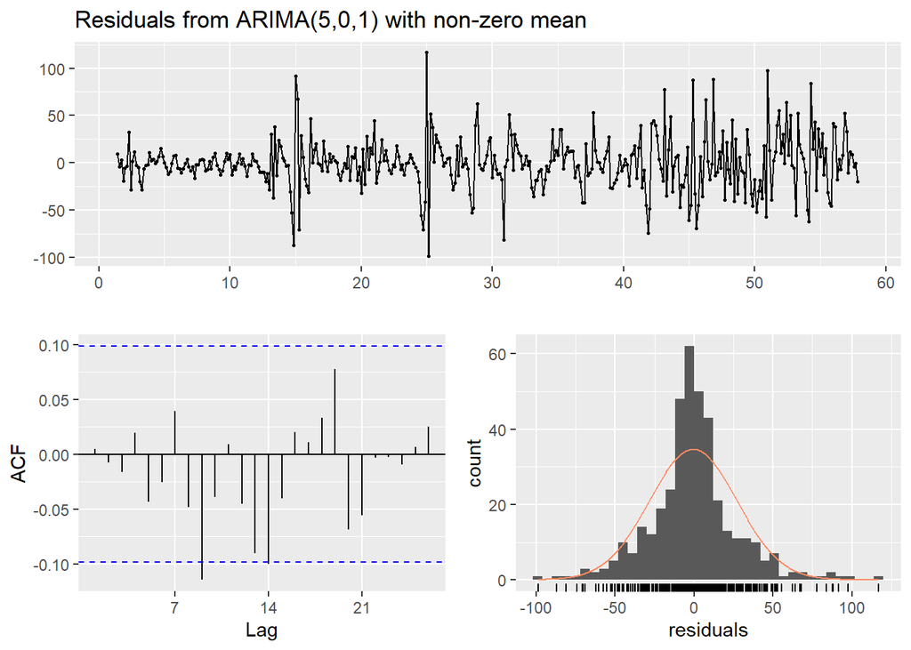

```
##
##  Ljung-Box test
##
## data:  Residuals from ARIMA(5,0,1) with non-zero mean
## Q* = 17.221, df = 7, p-value = 0.01602
##
## Model df: 7.   Total lags used: 14
```

```r
checkresiduals(arma_9_3)
```

```r
data_9[,fitted_3_0:=random_9-ar_9_1$residuals+dcmp_9$daily$trend+dcmp_9$daily$seasonal]
data_9[,fitted_4_0:=random_9-ar_9_2$residuals+dcmp_9$daily$trend+dcmp_9$daily$seasonal]
data_9[,fitted_5_0:=random_9-ar_9_3$residuals+dcmp_9$daily$trend+dcmp_9$daily$seasonal]
data_9[,fitted_3_1:=random_9-arma_9_1$residuals+dcmp_9$daily$trend+dcmp_9$daily$seasonal]
data_9[,fitted_4_1:=random_9-arma_9_2$residuals+dcmp_9$daily$trend+dcmp_9$daily$seasonal]
data_9[,fitted_5_1:=random_9-arma_9_3$residuals+dcmp_9$daily$trend+dcmp_9$daily$seasonal]

melted_result=melt(data_9, c("event_date","sold_count"),
                   c("fitted_3_0","fitted_4_0", "fitted_5_0", "fitted_3_1",
                     "fitted_4_1","fitted_5_1"))

performance=melted_result[,accu_na(sold_count, value), by=list(variable)]
performance
```

```
##      variable   n     mean       sd       CV         FBias MAPE     RMSE
## 1: fitted_3_0 396 94.64899 97.57656 1.030931  5.641024e-05  Inf 31.54206
## 2: fitted_4_0 396 94.64899 97.57656 1.030931  1.780942e-05  Inf 31.33921
## 3: fitted_5_0 396 94.64899 97.57656 1.030931 -8.579022e-05  Inf 30.36264
## 4: fitted_3_1 396 94.64899 97.57656 1.030931 -5.697865e-03  Inf 27.97254
## 5: fitted_4_1 396 94.64899 97.57656 1.030931 -5.771371e-03  Inf 27.96596
## 6: fitted_5_1 396 94.64899 97.57656 1.030931 -6.419869e-03  Inf 27.73332
##         MAD      MADP     WMAPE
## 1: 21.51925 0.2273585 0.2273585
## 2: 21.33853 0.2254491 0.2254491
## 3: 20.63617 0.2180284 0.2180284
## 4: 19.34245 0.2043598 0.2043598
## 5: 19.33976 0.2043314 0.2043314
## 6: 19.23685 0.2032441 0.2032441
```

We see that ARIMA(5,0,1) gives the best result.

Now we can add some regressors to the model. Again note that these are lagged variables.

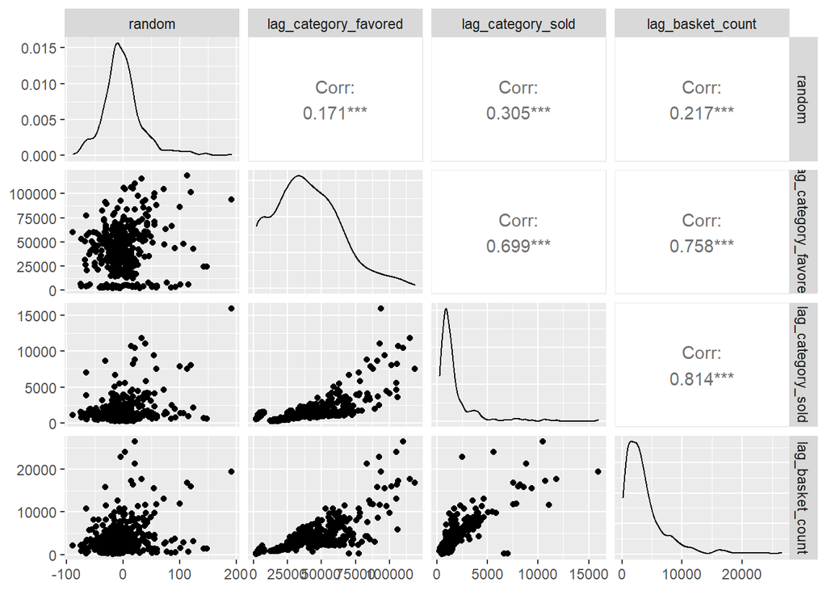

```r
ggpairs(data_9[,c("random","lag_category_favored","lag_category_sold","lag_basket_count")])
```

Now we try all three variables.

```r
lm_9=lm(random~lag_category_favored+lag_category_sold+lag_basket_count, data=data_9)
anova(lm_9)
```

```
## Analysis of Variance Table
##
## Response: random
##                       Df Sum Sq Mean Sq F value    Pr(>F)
## lag_category_favored   1  14832   14832 12.6436 0.0004229 ***
## lag_category_sold      1  34431   34431 29.3515 1.056e-07 ***
## lag_basket_count       1    470     470  0.4007 0.5271105
## Residuals            392 459842    1173
## ---
## Signif. codes:  0 '***' 0.001 '**' 0.01 '*' 0.05 '.' 0.1 ' ' 1
```

We can update the linear model according to the anova table.

```r
lm_9=lm(random~lag_category_favored+lag_category_sold, data=data_9)
summary(lm_9)
```

```
##
## Call:
## lm(formula = random ~ lag_category_favored + lag_category_sold,
##     data = data_9)
##
## Residuals:
##     Min      1Q  Median      3Q     Max
## -97.731 -19.657  -2.184  15.931 154.981
##
## Coefficients:
##                        Estimate Std. Error t value Pr(>|t|)
## (Intercept)          -7.422e+00  3.278e+00  -2.264   0.0241 *
## lag_category_favored -1.206e-04  9.673e-05  -1.247   0.2131
## lag_category_sold     7.015e-03  1.294e-03   5.422 1.03e-07 ***
## ---
## Signif. codes:  0 '***' 0.001 '**' 0.01 '*' 0.05 '.' 0.1 ' ' 1
##
## Residual standard error: 34.22 on 393 degrees of freedom
##   (6 observations deleted due to missingness)
## Multiple R-squared:  0.09667,    Adjusted R-squared:  0.09208
## F-statistic: 21.03 on 2 and 393 DF,  p-value: 2.106e-09
```

Only the `lag_category_sold` variable is significant. Now we compare ARIMA(5,0,1) and the new ARIMAX model on the test period.

```r
results=vector('list',length(test_dates))
for(i in 1:length(test_dates)){
  current_date=test_dates[i]-forecast_ahead

  past_data=data_9[event_date<=current_date]
  forecast_data=data_9[event_date==test_dates[i]]

  # arima model
  frcst=arima(past_data[,ts(random)], order=c(5,0,1))
  frcst=forecast(frcst, h=forecast_ahead)
  forecast_data[,arima_prediction:=round(frcst$mean[2]+as.numeric(trend)+as.numeric(seasonal), 0)]

  # arimax model
  reg = matrix(past_data[,lag_category_sold], ncol=1)
  frcst=auto.arima(past_data[,ts(random)],max.p=5,start.p=5,max.q=1,start.q=1,xreg=reg,seasonal=FALSE,stepwise=FALSE,approximation=FALSE)
  reg = matrix(past_data[(.N-1):.N, category_sold], ncol=1)
  frcst=forecast(frcst, h=forecast_ahead, xreg=reg)
  forecast_data[,arimax_prediction:=round(frcst$mean[2]+as.numeric(trend)+as.numeric(seasonal), 0)]

  results[[i]]=forecast_data
}
overall_results=rbindlist(results)
melted_result=melt(overall_results,c('event_date','sold_count'),
                   c('arima_prediction','arimax_prediction'))
performance= melted_result[,accu(sold_count,value),by=list(variable)]
performance
```

```
##             variable n     mean       sd        CV       FBias      MAPE
## 1:  arima_prediction 7 60.14286 31.16851 0.5182413  0.04038005 0.1959117
## 2: arimax_prediction 7 60.14286 31.16851 0.5182413 -0.13301663 0.2576262
##        RMSE      MAD      MADP     WMAPE
## 1: 16.19083 12.71429 0.2114014 0.2114014
## 2: 17.80851 14.28571 0.2375297 0.2375297
```

ARIMA model provides better results.

# Conclusion